# Lab 5: Causal Inference (Part I)

Author

Feng Qiu, Liyuan Xuan

Published

October 27, 2025

The development of Lab 5 is based on Chapter 4 of the textbook *[Causal Inference: The Mixtape](https://mixtape.scunning.com/04-potential_outcomes)* by Scott Cunningham.

## 1 Preparation

```r
library(dplyr)

patient_id  <- c(1 : 10)
life_state1 <- c(7, 5, 5, 7, 4, 10, 1, 5, 3, 9) # life span in state 1 (if surgery)
life_state0 <- c(1, 6, 1, 8, 2, 1, 10, 6, 7, 8) # life span in state 0 (if chemo)
```

## 2 Potential Outcomes Model

### 2.1 Observable Counterfactual

```r
df_ob <- data.frame(patient_id, life_state1, life_state0)
df_ob <- df_ob %>% mutate(delta_life = life_state1 - life_state0)
```

#### 2.1.1 Average Treatment Effect (ATE)

When the counterfactual is observable, we can calculate the ATE of the treatment surgery as

$$ATE = E[Life_i^1] - E[Life_i^0]$$

```r
ATE <- mean(df_ob$life_state1) - mean(df_ob$life_state0)
ATE
```

```
[1] 0.6
```

### 2.2 Treatment Assignment: Perfect Doctor

With a perfect doctor who assigns treatment only if patients benefit from it:

```r
df_ob <- df_ob %>% mutate(d_treat = ifelse(delta_life > 0, 1, 0))
df_ob
```

| patient_id | life_state1 | life_state0 | delta_life | d_treat |
| --- | --- | --- | --- | --- |
| 1 | 7 | 1 | 6 | 1 |
| 2 | 5 | 6 | -1 | 0 |
| 3 | 5 | 1 | 4 | 1 |
| 4 | 7 | 8 | -1 | 0 |
| 5 | 4 | 2 | 2 | 1 |
| 6 | 10 | 1 | 9 | 1 |
| 7 | 1 | 10 | -9 | 0 |
| 8 | 5 | 6 | -1 | 0 |
| 9 | 3 | 7 | -4 | 0 |
| 10 | 9 | 8 | 1 | 1 |

#### 2.2.1 Average Treatment Effect on the Treated (ATT)

$$ATT = E[Life_i^1|Treat=1] - E[Life_i^0|Treat=1]$$

```r
treated_ob <- df_ob %>% filter(d_treat == 1)

ATT <- mean(treated_ob$life_state1) - mean(treated_ob$life_state0)
ATT
```

```
[1] 4.4
```

#### 2.2.2 Average Treatment Effect on the Untreated (ATU)

$$ATU = E[Life_i^1|Treat=0] - E[Life_i^0|Treat=0]$$

```r
untreated_ob <- df_ob %>% filter(d_treat == 0)

ATU <- mean(untreated_ob$life_state1) - mean(untreated_ob$life_state0)
ATU
```

```
[1] -3.2
```

### 2.3 Weighted Average of ATT and ATU

$$ATE = \pi ATT + (1 - \pi) ATU, \text{where } \pi \text{ is the share of patients who received surgery}$$

```r
pi <- nrow(treated_ob) / nrow(df_ob)

w_ATT_ATU <- pi * ATT + (1 - pi) * ATU
w_ATT_ATU
```

```
[1] 0.6
```

### 2.4 Unobservable Counterfactual

In the real world, we cannot observe the counterfactual, but only (1) the actual lifespan and (2) whether patients received treatment.

```r
treated_unob   <- treated_ob   %>% select(-life_state0, -delta_life) %>% rename(life = life_state1)
untreated_unob <- untreated_ob %>% select(-life_state1, -delta_life) %>% rename(life = life_state0)

df_unob <- rbind(treated_unob, untreated_unob)
df_unob %>% arrange(patient_id)
```

| patient_id | life | d_treat |
| --- | --- | --- |
| 1 | 7 | 1 |
| 2 | 6 | 0 |
| 3 | 5 | 1 |
| 4 | 8 | 0 |
| 5 | 4 | 1 |
| 6 | 10 | 1 |
| 7 | 10 | 0 |
| 8 | 6 | 0 |
| 9 | 7 | 0 |
| 10 | 9 | 1 |

#### 2.4.1 Observed Difference in Means (ODM)

Given that,

$$ODM = E[Life_i^1|Treat=1] - E[Life_i^0|Treat=0]$$

```r
ODM <- mean(treated_unob$life) - mean(untreated_unob$life)
ODM
```

```
[1] -0.4
```

#### 2.4.2 Selection Bias

When selection bias is present, $ODM$ can be rewritten as,

$$\begin{aligned}
ODM &= E[Life_i^1|Treat=1] - E[Life_i^0|Treat=0]\\
&= (E[Life_i^1|Treat=1] - E[Life_i^0|Treat=1]) + (E[Life_i^0|Treat=1] - E[Life_i^0|Treat=0])\\
&= ATT + \text{Selection Bias}
\end{aligned}$$

```r
treated_state0_life   <- mean(treated_ob$life_state0)
untreated_state0_life <- mean(untreated_ob$life_state0)

selection_bias <- treated_state0_life - untreated_state0_life
selection_bias
```

```
[1] -4.8
```

```r
ATT + selection_bias
```

```
[1] -0.4
```

#### 2.4.3 Heterogeneous Treatment Effects Bias

Recall that

$$ATE = \pi ATT + (1-\pi) ATU$$
$ODM$ can also be rewritten into, when the heterogeneous treatment effects bias is present,

$$\begin{aligned}
ODM &= ATT + \text{Selection Bias}\\
&= ATE + \text{Selection Bias} + (1-\pi)(ATT-ATU) \\
&= ATE + \text{Selection Bias} + \text{Heterogeneous Treatment Effects Bias}
\end{aligned}$$

```r
H_treat_bias <- (1 - pi) * (ATT - ATU)
H_treat_bias
```

```
[1] 3.8
```

```r
ATE + selection_bias + H_treat_bias
```

```
[1] -0.4
```

**Note**

As shown above, in the presence of selection bias and/or heterogeneous treatment effects, the observed difference in means will not correctly capture the ATT or ATE.

- Selection bias: the inherent difference between the two groups of patients if both received chemo.
- Heterogeneous treatment effects: the difference in gains of the surgery between the group of patients who received surgery and the group who received chemo.

### 2.5 Regression and ODM

In a fully saturated model, the coefficient of “d_treat” exactly equals $ODM$.

```r
lm(life ~ d_treat, data = df_unob)
```

```
Call:
lm(formula = life ~ d_treat, data = df_unob)

Coefficients:
(Intercept)      d_treat
        7.4         -0.4
```

**Tip**

In this example, we are estimating the regression:
$$Life_i = \alpha + \beta Treat_i + \epsilon_i$$
It is called fully saturated, because the dummy “d_treat” can fully represents all the categories (or groups) in the data.

## 3 Randomized Controlled Trials

### 3.1 Independence Assumption

To correctly estimate $ATE$ via $ODM$, the Independence Assumption (IA) has to be satisfied for the treatment, which requires

$$(Y^1, Y^0) \perp\!\!\!\perp D$$

With large enough sample, randomized treatment can eliminate both selection bias and heterogeneous treatment effects bias.

### 3.2 Data Simulation

To demonstrate the claim above, we will use the same 10 observations of $Life^1$ and $Life^0$ repeatedly to generate a sample of 10/100/1,000/10,000/100,000 patients. But instead of a perfect doctor, we will randomly assign half of the patients to be “treated” each time a 10-observation sample is generated.

The final sample should simulate a world where 10/100/1,000/10,000/100,000 patients are randomly assigned surgery treatment, and we can only observe $Life^1$ for those who received treatment and $Life^0$ for those who did not.

```r
set.seed(1)

df_base <- function() {
  data.frame(life_state1, life_state0) %>%
    mutate(
      d_treat = ifelse(row_number() %in% sample(10, 5), 1, 0),
      life = ifelse(d_treat == 1, life_state1, life_state0)
    )
}

df_sim10 <- bind_rows(replicate(1, df_base(), simplify = FALSE))
df_sim100 <- bind_rows(replicate(10, df_base(), simplify = FALSE))
df_sim1000 <- bind_rows(replicate(100, df_base(), simplify = FALSE))
df_sim10000 <- bind_rows(replicate(1000, df_base(), simplify = FALSE))
df_sim100000 <- bind_rows(replicate(10000, df_base(), simplify = FALSE))
```

### 3.3 Calculate ODM

```r
ODM1 <- mean(df_sim10$life_state1[df_sim10$d_treat == 1]) - mean(df_sim10$life_state0[df_sim10$d_treat == 0])
ODM2 <- mean(df_sim100$life_state1[df_sim100$d_treat == 1]) - mean(df_sim100$life_state0[df_sim100$d_treat == 0])
ODM3 <- mean(df_sim1000$life_state1[df_sim1000$d_treat == 1]) - mean(df_sim1000$life_state0[df_sim1000$d_treat == 0])
ODM4 <- mean(df_sim10000$life_state1[df_sim10000$d_treat == 1]) - mean(df_sim10000$life_state0[df_sim10000$d_treat == 0])
ODM5 <- mean(df_sim100000$life_state1[df_sim100000$d_treat == 1]) - mean(df_sim100000$life_state0[df_sim100000$d_treat == 0])

ODMs <- c(ODM1, ODM2, ODM3, ODM4, ODM5)
names(ODMs) <- c("times1", "times10", "times100", "times1000", "times10000")
ODMs
```

```
    times1    times10   times100  times1000 times10000
   1.00000    0.68000    0.77600    0.66280    0.61022
```

### 3.4 Regression

```r
lm1 <- lm(life ~ d_treat, data = df_sim10)
lm2 <- lm(life ~ d_treat, data = df_sim100)
lm3 <- lm(life ~ d_treat, data = df_sim1000)
lm4 <- lm(life ~ d_treat, data = df_sim10000)
lm5 <- lm(life ~ d_treat, data = df_sim100000)

library(stargazer)
stargazer(lm1, lm2, lm3, lm4, lm5,
          omit.stat = c("f", "ser", "rsq", "adj.rsq"),
          type = "text",
          omit = "Constant",
          star.cutoffs = NA,
          digits = 2,
          intercept.bottom = TRUE,
          dep.var.caption = "Lifespan",
          dep.var.labels.include = FALSE,
          model.numbers = FALSE,
          column.labels = c("times1", "times10", "times100", "times1000", "times10000"),
          no.space = TRUE,
          font.size = "footnotesize"
          )
```

```
=========================================================
                               Lifespan
             --------------------------------------------
             times1 times10 times100 times1000 times10000
---------------------------------------------------------
d_treat       1.00   0.68     0.78     0.66       0.61
             (1.85) (0.61)   (0.19)   (0.06)     (0.02)
---------------------------------------------------------
Observations   10     100    1,000    10,000    100,000
=========================================================
Note:                                                  NA
```

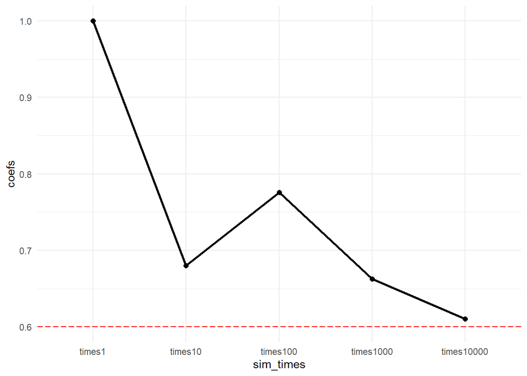

```r
sim_times <- factor(c("times1", "times10", "times100", "times1000", "times10000"),
                      levels = c("times1", "times10", "times100", "times1000", "times10000"))
coefs <- c(lm1$coefficients[2], lm2$coefficients[2], lm3$coefficients[2], lm4$coefficients[2], lm5$coefficients[2])

models <- data.frame(sim_times, coefs)

library(ggplot2)

ggplot(models, aes(x = sim_times, y = coefs, group = 1)) +
  geom_point(size = 2) +
  geom_line(linewidth = 1) +
  geom_hline(yintercept = 0.6, linetype = "longdash", color = "red") +
  theme_minimal()
```

Overall, we observe that with (1) random treatment and (2) large sample, the ODM converges to the true ATE.

## 4 Exercise

Use the following dataset on 10 farmers that:

- a potential profit $profit^1$ is realized if the new technology is adopted, otherwise $profit^0$
- the counterfactual is observable

Answer Question 1 and 2.

```r
farmer_id <- 1 : 10
profit_state1 <- c(120, 90, 90, 150, 80, 160, 60, 95, 100, 75)    # adoption of the technology
profit_state0 <- c(100, 95, 85, 110, 90, 100, 70, 90, 80, 100)    # no adoption
```

1. Suppose the farmers will only adopt the technology if it is profitable, generate the dummy variable “d_adopt”.
2. Calculate $ATE$, $ATT$, $ATU$, and show that $ATE$ is the weighted average of the other two terms.

Now, imagine a more realistic situation where the counterfactual is not observable, and only the realized profits and whether the farms adopted the technology can be observed.

Create this new data frame and answer Question 3 through 5.

3. Calculate the $ODM$ and verify that the regression results correspond to it.
4. Calculate the selection bias and the heterogeneous treatment effects bias.
5. Simulate a sample of 10,000 observations by repeatedly using the same 10 observations on the farmers, with only 6 out of 10 farmers adopt the technology randomly each time. Show that when estimating a regression, the coefficient of “d_adopt” approaches the true ATE.